# **Pseudotimes and cell fates**

**Motivation:**

While clustering is an useful type of analysis to try giving a structure to the development of cells towards their final stage (spermatozoa), it does not give an understanding of how the development "stretches" from start to end. For example, a cluster can have many cells and look "big" on UMAP, but actually its variability in terms of gene expressions could be low. Also, a developmental process can branches towards different ends (cell fates) or developmental checkpoints (e.g. stages where damaged cells express specific genes for apoptosis/cell death). Pseudotime and cell fates analysis can be used to hgihlight exactly those processes.

- **Pseudotimes** assigns to each cell the value of a timeline, starting from 0 for the cells at the beginning of the development. This value is purely a reference for ordering the cells development, but pseudotimes at specific stages can be assigned to real times, using previous biological knowledge.
- **Cell fates analysis** looks at the PCA projection of the data and the pseudotime of each data point on the PCA. From this, it tries to create a tree connecting the cells, so that the end branches of the tree are different end points or stages of the developmental process.

[figure not shown]

*Figure: cell fates tree on a 3D pca plot. Circles represent the middle point of each cluster. From Perredaeau et al. (2017)*

**Learning objectives:**

- Understand and determine the pseudotimes on a single cell dataset
- Infer cell fates and distinguish between differentiation stages or actual final developmental stages
- Compare gene expressions along differentiation
- Cluster genes with similar gene expression

**Execution time: 45 minutes**

*Import packages*

```python
import scanpy as sc
import pandas as pd
import scvelo as scv
import numpy as np
import seaborn as sns
import matplotlib.pyplot as plt
import sklearn
import anndata as ad
```

import scanpy as sc import pandas as pd import scvelo as scv import numpy as np import seaborn as sns import matplotlib.pyplot as plt import sklearn import anndata as ad

```python
import rpy2.rinterface_lib.callbacks
import logging

from rpy2.robjects import pandas2ri
import anndata2ri

# Ignore R warning messages
#Note: this can be commented out to get more verbose R output
rpy2.rinterface_lib.callbacks.logger.setLevel(logging.ERROR)

# Automatically convert rpy2 outputs to pandas dataframes
pandas2ri.activate()
anndata2ri.activate()

#import os
#os.environ['R_HOME'] = '../../../scrna-environment/lib/R/' #path to your R installation

%load_ext rpy2.ipython
```

import rpy2.rinterface_lib.callbacks import logging from rpy2.robjects import pandas2ri import anndata2ri # Ignore R warning messages #Note: this can be commented out to get more verbose R output rpy2.rinterface_lib.callbacks.logger.setLevel(logging.ERROR) # Automatically convert rpy2 outputs to pandas dataframes pandas2ri.activate() anndata2ri.activate() #import os #os.environ['R_HOME'] = '../../../scrna-environment/lib/R/' #path to your R installation %load_ext rpy2.ipython

```python
%%R
.libPaths( c( "../../../../sandbox_scRNA_testAndFeedback/scrna-environment/lib/R/library/" ) )
```

%%R .libPaths( c( "../../../../sandbox_scRNA_testAndFeedback/scrna-environment/lib/R/library/" ) )

```python
%matplotlib inline
```

%matplotlib inline

*Read data*

```python
sample = sc.read('../../Data/notebooks_data/sample_123.filt.norm.red.clst.2.h5ad')
```

sample = sc.read('../../Data/notebooks_data/sample_123.filt.norm.red.clst.2.h5ad')

```
WARNING: Your filename has more than two extensions: ['.filt', '.norm', '.red', '.clst', '.2', '.h5ad'].
Only considering the two last: ['.2', '.h5ad'].
WARNING: Your filename has more than two extensions: ['.filt', '.norm', '.red', '.clst', '.2', '.h5ad'].
Only considering the two last: ['.2', '.h5ad'].
```

## Calculate pseudotimes and cell fates

We want to calculate pseudotimes on the spermatogenic process. We exclude the somatic cells from.

```python
cellsToKeep = [ i not in ['Somatic'] for i in sample.obs['clusters_spc'] ]
sample = sample[ cellsToKeep, : ].copy()
```

cellsToKeep = [ i not in ['Somatic'] for i in sample.obs['clusters_spc'] ] sample = sample[ cellsToKeep, : ].copy()

we use the `python` package `palantir`

```python
import palantir
palantir.core.random.seed( a=12345 ) #define random_state (here called 'a')
```

import palantir palantir.core.random.seed( a=12345 ) #define random_state (here called 'a')

```
findfont: Font family ['Raleway'] not found. Falling back to DejaVu Sans.
findfont: Font family ['Lato'] not found. Falling back to DejaVu Sans.
```

we create a table (`pandas` dataframe) with the logarithm of the corrected UMI matrix, since `palantir` needs logarithmized raw counts in input

```python
palantir_data = pd.DataFrame(np.log1p(sample.layers['umi_sct'].todense()),
                             index=sample.obs_names,
                             columns=sample.var_names)
```

palantir_data = pd.DataFrame(np.log1p(sample.layers['umi_sct'].todense()), index=sample.obs_names, columns=sample.var_names)

Instead of letting the package calculate the PCA (without any form of datasets integration), we use our integrated PCA.

```python
pca_projections = pd.DataFrame( sample.obsm['X_pca'][:,0:15].copy(),
                                index=sample.obs_names )
```

pca_projections = pd.DataFrame( sample.obsm['X_pca'][:,0:15].copy(), index=sample.obs_names )

```python
ORIGIN_STATE = 'SpermatogoniaA' #where to start
sc.tl.diffmap(sample)
diffusionMap = pd.DataFrame(sample.obsm['X_diffmap'][:,1::],
                             index=sample.obs_names,
                             columns = [str(i) for i in range(sample.obsm['X_diffmap'].shape[1]-1)])
#apply palantir
start_cell = str(sample[sample.obs['clusters_spc'] == ORIGIN_STATE].obs_names[0]) #assignment of diferentiation start
pr_res = palantir.core.run_palantir( diffusionMap, early_cell=start_cell, num_waypoints=1000) #fate detection
```

ORIGIN_STATE = 'SpermatogoniaA' #where to start sc.tl.diffmap(sample) diffusionMap = pd.DataFrame(sample.obsm['X_diffmap'][:,1::], index=sample.obs_names, columns = [str(i) for i in range(sample.obsm['X_diffmap'].shape[1]-1)]) #apply palantir start_cell = str(sample[sample.obs['clusters_spc'] == ORIGIN_STATE].obs_names[0]) #assignment of diferentiation start pr_res = palantir.core.run_palantir( diffusionMap, early_cell=start_cell, num_waypoints=1000) #fate detection

```
Sampling and flocking waypoints...
Time for determining waypoints: 0.008485527833302815 minutes
Determining pseudotime...
Shortest path distances using 30-nearest neighbor graph...
```

[output not shown]

[output cut: 9 more lines]

[output not shown]

```
Time for shortest paths: 0.20841457843780517 minutes
Iteratively refining the pseudotime...
Correlation at iteration 1: 1.0000
Entropy and branch probabilities...
Markov chain construction...
Identification of terminal states...
Computing fundamental matrix and absorption probabilities...
Project results to all cells...
```

We save pseudotimes in our dataset and plot them on UMAP

```python
sample.obs['pseudotime'] = pr_res.pseudotime
```

sample.obs['pseudotime'] = pr_res.pseudotime

```python
sc.pl.umap( sample, color=['clusters_spc','pseudotime'],
           legend_loc='on data',
           legend_fontsize=16,
           ncols=2 )
```

[output not shown]

sc.pl.umap( sample, color=['clusters_spc','pseudotime'], legend_loc='on data', legend_fontsize=16, ncols=2 )

```
findfont: Font family ['Bitstream Vera Sans'] not found. Falling back to DejaVu Sans.
findfont: Font family ['Bitstream Vera Sans'] not found. Falling back to DejaVu Sans.
findfont: Font family ['Bitstream Vera Sans'] not found. Falling back to DejaVu Sans.
```

```python
cluster_names = [i for i in ['SpermatogoniaA', 'SpermatogoniaB', 'Leptotene', 'Zygotene',
                   'Pachytene', 'SpermatocitesII', 'Diplotene', 'RoundSpermatids',
                   'ElongSpermatids'] if i in np.array(sample.obs['clusters_spc']) ]
sc.pl.violin(sample, keys='pseudotime', groupby='clusters_spc', rotation=90,
            order=cluster_names)
```

cluster_names = [i for i in ['SpermatogoniaA', 'SpermatogoniaB', 'Leptotene', 'Zygotene', 'Pachytene', 'SpermatocitesII', 'Diplotene', 'RoundSpermatids', 'ElongSpermatids'] if i in np.array(sample.obs['clusters_spc']) ] sc.pl.violin(sample, keys='pseudotime', groupby='clusters_spc', rotation=90, order=cluster_names)

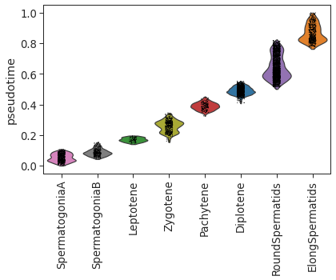

## Analysis of cell fates

we can see how many fates we have. For each fate, there is the barcode of the cell best representing a differentiation stage. In some cases you can have more than two fates

```python
fates = list(pr_res.branch_probs.columns)
```

fates = list(pr_res.branch_probs.columns)

```python
fates
```

fates

```
['TCCCGATGTAGCGTGA-1-0']
```

```python
f, ax = plt.subplots(1,1)

sc.pl.umap( sample,
           legend_loc='on data',
           legend_fontsize=16, ax=ax, show=False)

coordinates = sample[fates].obsm['X_umap']
ax.plot(coordinates[:,0],coordinates[:,1],'o',markersize=12)
for i in range(coordinates.shape[0]):
    ax.text(coordinates[i,0]-1,coordinates[i,1]-2, f'Fate {i}')
    ax.set_title("Inferred cell fates")
plt.show()
```

f, ax = plt.subplots(1,1) sc.pl.umap( sample, legend_loc='on data', legend_fontsize=16, ax=ax, show=False) coordinates = sample[fates].obsm['X_umap'] ax.plot(coordinates[:,0],coordinates[:,1],'o',markersize=12) for i in range(coordinates.shape[0]): ax.text(coordinates[i,0]-1,coordinates[i,1]-2, f'Fate {i}') ax.set_title("Inferred cell fates") plt.show()

```
findfont: Font family ['Bitstream Vera Sans'] not found. Falling back to DejaVu Sans.
```

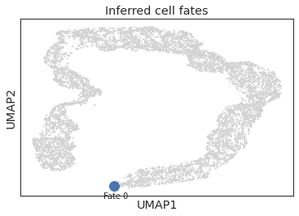

We rename the fates as follows instead of using cell barcodes

```python
fates = np.array( pr_res.branch_probs.columns )
for i in range(coordinates.shape[0]):
    fates[i] = f'Fate {i}'
pr_res.branch_probs.columns = fates
```

fates = np.array( pr_res.branch_probs.columns ) for i in range(coordinates.shape[0]): fates[i] = f'Fate {i}' pr_res.branch_probs.columns = fates

We save in our data the probability that each cell differentiate into one of the fates

```python
for i in pr_res.branch_probs.columns:
    sample.obs[f'branch_prob_{i}'] = pr_res.branch_probs[i]
```

for i in pr_res.branch_probs.columns: sample.obs[f'branch_prob_{i}'] = pr_res.branch_probs[i]

### Recognizing branchings or developmental stages

A good practice is to look at the probabilities of ending in a fate for each cluster. There are two possible scenarios:

- only one fate: all cells have probability 1 of ending at a specific cell fate
- more than one cell fate: some fates are actual branchings of the developmental process, and only some cells will have a probability of ending up in those branchings. Some other fates are just midpoints of the developmental process. Here, they will absorb with probability 1 entire sections of the dataset.

We plot below the probability of each cell (seen by cluster) to end up in a specific fate. Each violin plot corresponds to a single fate.

```python
for i in range(coordinates.shape[0]):
    x = sc.pl.violin(sample, groupby='clusters_spc', keys=f'branch_prob_Fate {i}', rotation=90,
            order=cluster_names, ylabel=f'Probability of Fate {i}')
```

for i in range(coordinates.shape[0]): x = sc.pl.violin(sample, groupby='clusters_spc', keys=f'branch_prob_Fate {i}', rotation=90, order=cluster_names, ylabel=f'Probability of Fate {i}')

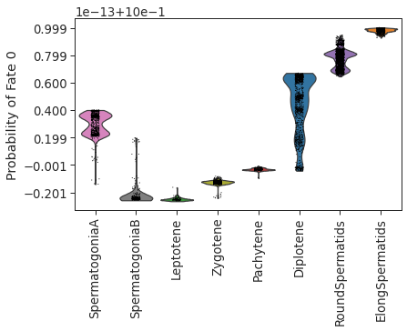

### Exploring gene expression and clusters

Here is a script that plots gene expressions of your choice along pseudotimes. This allows you to see how specific genes behave differently for different fates. Expressions are modeled using the fate probabilities we plotted above.

```python
import palantir
```

import palantir

```python
GENES = ['PIWIL1','PIWIL2','PIWIL3']
GENES = np.intersect1d(GENES, sample.var_names)
NGENES = len(GENES)
CLUSTERS = sample.obs['clusters_spc']
PSEUDOTIMES = sample.obs['pseudotime']
gene_trends = palantir.presults.compute_gene_trends(pr_res,
                                                    pd.DataFrame(sample.layers['norm_sct'],
                                                    index=sample.obs_names,
                                                    columns=sample.var_names).loc[:, GENES]
                                                   )

plt.rcParams['figure.figsize']=(12,4*int(NGENES))
fig, ax = plt.subplots(NGENES,1)

c = CLUSTERS
x = PSEUDOTIMES


if(NGENES==1):
    x2 = []
    t = []
    style = []
    for FATE in list(gene_trends.keys()):
        ARRAY = np.array( gene_trends[FATE]['trends'].loc[GENES[0],:].index )
        for i in ARRAY:
            idx = np.argmin(np.abs(x - i))
            x2.append(c[idx])
            t.append(i)
        if(len(style)==0):
            style = np.tile( FATE, 500 )
            y = np.array(gene_trends[FATE]['trends'].loc[GENES[0],:])
        else:
            style = np.append(arr=style,
                      values=np.tile( FATE, 500 ))
            y = np.append(arr=y,
                      values=np.array(gene_trends[FATE]['trends'].loc[GENES[0],:]))

    sns.lineplot(x=t,
             y=y, ci=False,
             hue=x2, ax=ax, style = style,
             linewidth = 5)
    ax.legend(bbox_to_anchor=(1.05, 1), loc=2, borderaxespad=0.)
    ax.set(xlabel = 'Pseudotime', ylabel=GENES[0])

if(NGENES>1):
    for GENE_NR in range(NGENES):
        style = []
        x2 = []
        t = []
        for FATE in list(gene_trends.keys()):
            ARRAY = np.array( gene_trends[FATE]['trends'].loc[GENES[GENE_NR],:].index )
            for i in ARRAY:
                idx = np.argmin(np.abs(x - i))
                x2.append(c[idx])
                t.append(i)
            if(len(style)==0):
                style = np.tile( FATE, 500 )
                y = np.array(gene_trends[FATE]['trends'].loc[GENES[GENE_NR],:])
            else:
                style = np.append(arr=style,
                              values=np.tile( FATE, 500 ))
                y = np.append(arr=y,
                              values=np.array(gene_trends[FATE]['trends'].loc[GENES[GENE_NR],:]))
        sns.lineplot(x=t,
                             y=y, ci=False,
                             hue=x2, ax=ax[GENE_NR],
                             style = style, linewidth = 5, legend=GENE_NR==0)
        ax[GENE_NR].set(ylabel = GENES[GENE_NR])
        if(GENE_NR==0):
            ax[0].legend(bbox_to_anchor=(1.05, 1), loc=2, borderaxespad=0.)
            ax[0].set_title(f'Gene expression along the fates:\n{list(gene_trends.keys())}')
    ax[GENE_NR].set(xlabel = 'Pseudotime')

plt.rcParams['figure.figsize']=(6,6)
```

GENES = ['PIWIL1','PIWIL2','PIWIL3'] GENES = np.intersect1d(GENES, sample.var_names) NGENES = len(GENES) CLUSTERS = sample.obs['clusters_spc'] PSEUDOTIMES = sample.obs['pseudotime'] gene_trends = palantir.presults.compute_gene_trends(pr_res, pd.DataFrame(sample.layers['norm_sct'], index=sample.obs_names, columns=sample.var_names).loc[:, GENES] ) plt.rcParams['figure.figsize']=(12,4*int(NGENES)) fig, ax = plt.subplots(NGENES,1) c = CLUSTERS x = PSEUDOTIMES if(NGENES==1): x2 = [] t = [] style = [] for FATE in list(gene_trends.keys()): ARRAY = np.array( gene_trends[FATE]['trends'].loc[GENES[0],:].index ) for i in ARRAY: idx = np.argmin(np.abs(x - i)) x2.append(c[idx]) t.append(i) if(len(style)==0): style = np.tile( FATE, 500 ) y = np.array(gene_trends[FATE]['trends'].loc[GENES[0],:]) else: style = np.append(arr=style, values=np.tile( FATE, 500 )) y = np.append(arr=y, values=np.array(gene_trends[FATE]['trends'].loc[GENES[0],:])) sns.lineplot(x=t, y=y, ci=False, hue=x2, ax=ax, style = style, linewidth = 5) ax.legend(bbox_to_anchor=(1.05, 1), loc=2, borderaxespad=0.) ax.set(xlabel = 'Pseudotime', ylabel=GENES[0]) if(NGENES>1): for GENE_NR in range(NGENES): style = [] x2 = [] t = [] for FATE in list(gene_trends.keys()): ARRAY = np.array( gene_trends[FATE]['trends'].loc[GENES[GENE_NR],:].index ) for i in ARRAY: idx = np.argmin(np.abs(x - i)) x2.append(c[idx]) t.append(i) if(len(style)==0): style = np.tile( FATE, 500 ) y = np.array(gene_trends[FATE]['trends'].loc[GENES[GENE_NR],:]) else: style = np.append(arr=style, values=np.tile( FATE, 500 )) y = np.append(arr=y, values=np.array(gene_trends[FATE]['trends'].loc[GENES[GENE_NR],:])) sns.lineplot(x=t, y=y, ci=False, hue=x2, ax=ax[GENE_NR], style = style, linewidth = 5, legend=GENE_NR==0) ax[GENE_NR].set(ylabel = GENES[GENE_NR]) if(GENE_NR==0): ax[0].legend(bbox_to_anchor=(1.05, 1), loc=2, borderaxespad=0.) ax[0].set_title(f'Gene expression along the fates:\n{list(gene_trends.keys())}') ax[GENE_NR].set(xlabel = 'Pseudotime') plt.rcParams['figure.figsize']=(6,6)

```
Fate 0
```

[output not shown]

```
Time for processing Fate 0: 0.4374883691469828 minutes
```

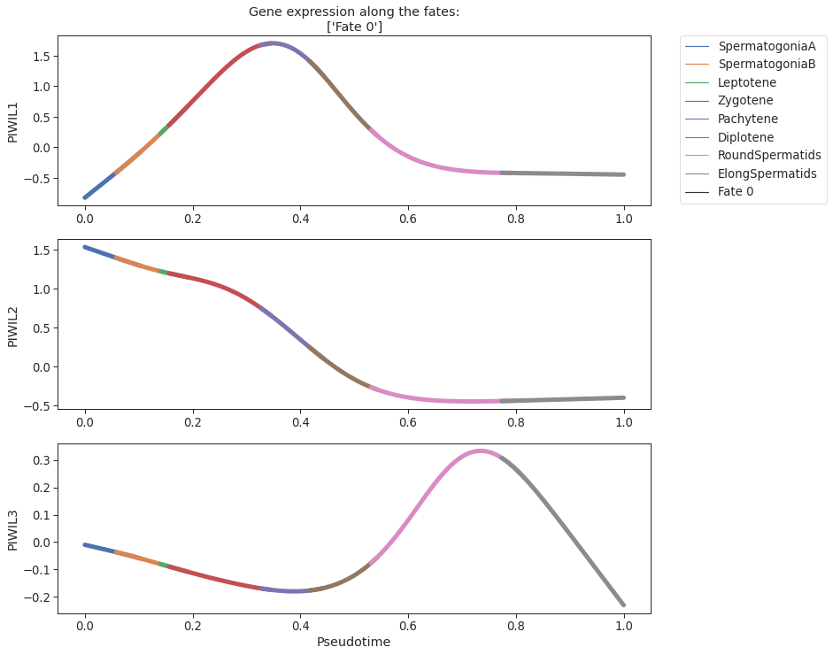

**Gene clustering:** A last thing you can do is to cluster together genes that have the same expression patterns. We can try to do this for each different fate. Here you can only look at one fate at a time

For making the clustering faster, we cluster together only the differentially expressed genes we found in the previous analysis. However, below you can define the variable `genes` as any list of genes. You can for example read them from a text file, or you can use all possible genes by writing `genes=list(sample.var_names)`

```python
genes = []
for names in sample.uns['DE_clusters_spc']['names']:
    genes.append( list( names ) )
```

genes = [] for names in sample.uns['DE_clusters_spc']['names']: genes.append( list( names ) )

```python
genes = np.unique(np.ravel(genes))
```

genes = np.unique(np.ravel(genes))

model the gene expression along pseudotime

```python
gene_trends = palantir.presults.compute_gene_trends( pr_res,
                                         pd.DataFrame(sample[ :, genes ].layers['norm_sct'],
                                         index=sample[ :, genes ].obs_names,
                                         columns=sample[ :, genes ].var_names) )
```

gene_trends = palantir.presults.compute_gene_trends( pr_res, pd.DataFrame(sample[ :, genes ].layers['norm_sct'], index=sample[ :, genes ].obs_names, columns=sample[ :, genes ].var_names) )

```
Fate 0
```

[output not shown]

```
Time for processing Fate 0: 0.17321434020996093 minutes
```

```python
trends = gene_trends['Fate 0']['trends']
gene_clusters = palantir.presults.cluster_gene_trends(trends, k=20)
```

trends = gene_trends['Fate 0']['trends'] gene_clusters = palantir.presults.cluster_gene_trends(trends, k=20)

```
Finding 20 nearest neighbors using minkowski metric and 'auto' algorithm
Neighbors computed in 0.10072517395019531 seconds
Jaccard graph constructed in 1.2222075462341309 seconds
Wrote graph to binary file in 0.007137298583984375 seconds
Running Louvain modularity optimization
After 1 runs, maximum modularity is Q = 0.801915
Louvain completed 21 runs in 1.2909739017486572 seconds
Sorting communities by size, please wait ...
PhenoGraph completed in 3.943619966506958 seconds
```

```python
palantir.plot.plot_gene_trend_clusters(trends, gene_clusters)
```

palantir.plot.plot_gene_trend_clusters(trends, gene_clusters)

```
findfont: Font family ['Bitstream Vera Sans'] not found. Falling back to DejaVu Sans.
findfont: Font family ['Bitstream Vera Sans'] not found. Falling back to DejaVu Sans.
```

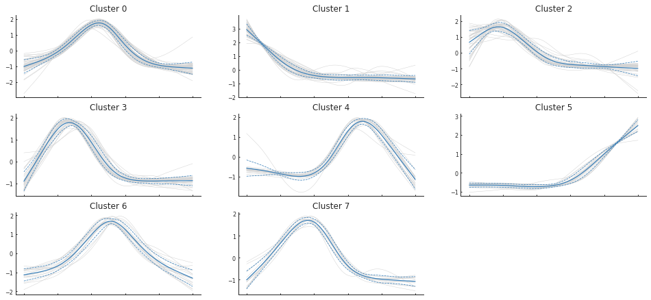

Here is a script to produce the plot as above, with averaged expression of each gene cluster coloured by cell types, together with confidence bands. It takes some time to do all the plots, so be patient.

```python
GENE_CLST = np.array(gene_clusters)
UNIQUE_CLST = np.sort(np.unique(GENE_CLST))
CLST_NR = int(len(UNIQUE_CLST))
CLUSTERS = sample.obs['clusters_spc']
PSEUDOTIMES = sample.obs['pseudotime']

plt.rcParams['figure.figsize']=(12,4*CLST_NR)
fig, ax = plt.subplots(CLST_NR,1)

c = CLUSTERS
x = PSEUDOTIMES

if(CLST_NR==1):
    t = []
    x2 = []
    ARRAY = np.array( trends.columns )
    for i in ARRAY:
        idx = np.argmin(np.abs(x - i))
        x2.append(c[idx])
        t.append(i)

    x=np.tile(ARRAY,trends.loc[GENE_CLST==0,:].shape[0])
    y=np.array(trends.loc[GENE_CLST==0,:]).ravel()
    hue=np.tile(x2,trends.loc[GENE_CLST==0,:].shape[0])
    ax = sns.lineplot(x=x, y=y, hue=hue)

    sns.lineplot(x=x, y=y, hue=hue,
                 ax=ax, linewidth = 5)
    ax.legend(bbox_to_anchor=(1.05, 1), loc=2, borderaxespad=0.)


if(CLST_NR>1):
    ARRAY = np.array( trends.columns )
    t = []
    x2 = []
    for i in ARRAY:
        idx = np.argmin(np.abs(x - i))
        x2.append(c[idx])
        t.append(i)
    for CLST_NR in UNIQUE_CLST:
        x=np.tile(ARRAY,trends.loc[GENE_CLST==CLST_NR,:].shape[0])
        y=np.array(trends.loc[GENE_CLST==CLST_NR,:]).ravel()
        hue=np.tile(x2,trends.loc[GENE_CLST==CLST_NR,:].shape[0])

        sns.lineplot(x=x, y=y, hue=hue,
                 ax=ax[CLST_NR], linewidth = 5, legend=CLST_NR==0)
        ax[CLST_NR].set(ylabel = f'Cluster {CLST_NR}')
        if(CLST_NR==0):
            ax[CLST_NR].legend(bbox_to_anchor=(1.05, 1), loc=2, borderaxespad=0.)
            ax[CLST_NR].set_title('Gene expression clustering for cell fate 0')
    ax[CLST_NR].set(xlabel = 'Pseudotime')

plt.rcParams['figure.figsize']=(6,6)
```

GENE_CLST = np.array(gene_clusters) UNIQUE_CLST = np.sort(np.unique(GENE_CLST)) CLST_NR = int(len(UNIQUE_CLST)) CLUSTERS = sample.obs['clusters_spc'] PSEUDOTIMES = sample.obs['pseudotime'] plt.rcParams['figure.figsize']=(12,4*CLST_NR) fig, ax = plt.subplots(CLST_NR,1) c = CLUSTERS x = PSEUDOTIMES if(CLST_NR==1): t = [] x2 = [] ARRAY = np.array( trends.columns ) for i in ARRAY: idx = np.argmin(np.abs(x - i)) x2.append(c[idx]) t.append(i) x=np.tile(ARRAY,trends.loc[GENE_CLST==0,:].shape[0]) y=np.array(trends.loc[GENE_CLST==0,:]).ravel() hue=np.tile(x2,trends.loc[GENE_CLST==0,:].shape[0]) ax = sns.lineplot(x=x, y=y, hue=hue) sns.lineplot(x=x, y=y, hue=hue, ax=ax, linewidth = 5) ax.legend(bbox_to_anchor=(1.05, 1), loc=2, borderaxespad=0.) if(CLST_NR>1): ARRAY = np.array( trends.columns ) t = [] x2 = [] for i in ARRAY: idx = np.argmin(np.abs(x - i)) x2.append(c[idx]) t.append(i) for CLST_NR in UNIQUE_CLST: x=np.tile(ARRAY,trends.loc[GENE_CLST==CLST_NR,:].shape[0]) y=np.array(trends.loc[GENE_CLST==CLST_NR,:]).ravel() hue=np.tile(x2,trends.loc[GENE_CLST==CLST_NR,:].shape[0]) sns.lineplot(x=x, y=y, hue=hue, ax=ax[CLST_NR], linewidth = 5, legend=CLST_NR==0) ax[CLST_NR].set(ylabel = f'Cluster {CLST_NR}') if(CLST_NR==0): ax[CLST_NR].legend(bbox_to_anchor=(1.05, 1), loc=2, borderaxespad=0.) ax[CLST_NR].set_title('Gene expression clustering for cell fate 0') ax[CLST_NR].set(xlabel = 'Pseudotime') plt.rcParams['figure.figsize']=(6,6)

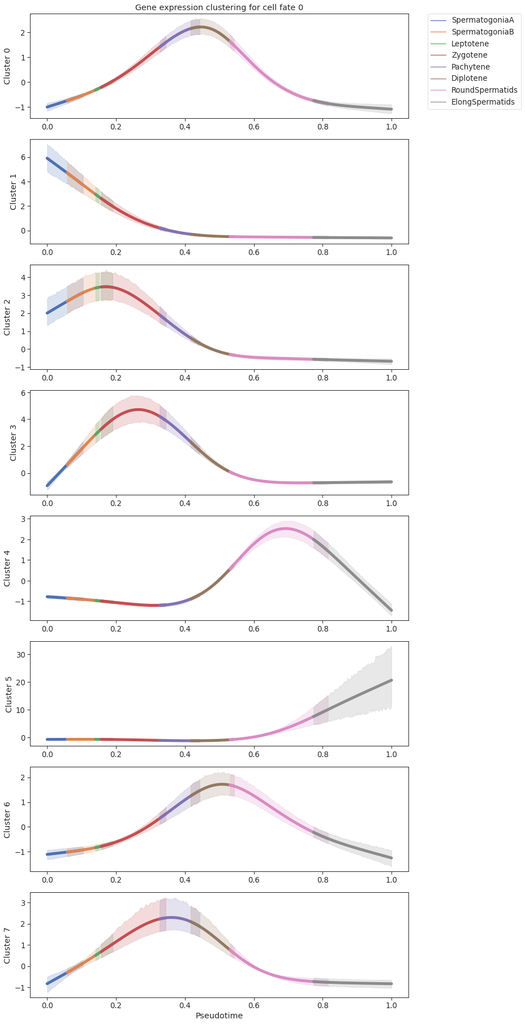

you can always look at the genes in a specific cluster. In this case, each cluster should be quite matching the differentially expressed genes for a cell type, since we grouped together differentially expressed genes

```python
gene_clusters[gene_clusters==5]
```

gene_clusters[gene_clusters==5]

```
AC010255.3    5
C10orf62      5
DCUN1D1       5
FNDC8         5
GAPDHS        5
GLUL          5
HMGB4         5
IQCF1         5
LELP1         5
LINC01921     5
OAZ3          5
ODF2          5
P3R3URF       5
PRM1          5
PRM2          5
SPATA3        5
TEX37         5
TEX44         5
TNP1          5
TSSK6         5
dtype: int64
```

We also want to save the dataset (including somatic cells) with pseudotimes. To do this we reopen the whole dataset and assign pseudotimes equal to 0 to the somatic cell.

```python
whole_sample = sc.read('../../Data/notebooks_data/sample_123.filt.norm.red.clst.2.h5ad')
```

whole_sample = sc.read('../../Data/notebooks_data/sample_123.filt.norm.red.clst.2.h5ad')

```
WARNING: Your filename has more than two extensions: ['.filt', '.norm', '.red', '.clst', '.2', '.h5ad'].
Only considering the two last: ['.2', '.h5ad'].
WARNING: Your filename has more than two extensions: ['.filt', '.norm', '.red', '.clst', '.2', '.h5ad'].
Only considering the two last: ['.2', '.h5ad'].
```

```python
times = pd.Series(sample.obs['pseudotime'], index=sample.obs_names)
whole_times = pd.Series(index=whole_sample.obs_names)
names = sample.obs_names
whole_names = whole_sample.obs_names
whole_times = [ times[i] if i in names else 0 for i in whole_names ]
```

times = pd.Series(sample.obs['pseudotime'], index=sample.obs_names) whole_times = pd.Series(index=whole_sample.obs_names) names = sample.obs_names whole_names = whole_sample.obs_names whole_times = [ times[i] if i in names else 0 for i in whole_names ]

```python
whole_sample.obs['pseudotimes'] = whole_times
```

whole_sample.obs['pseudotimes'] = whole_times

```python
whole_sample.write('../../Data/notebooks_data/sample_123.filt.norm.red.clst.2.times.h5ad')
```

whole_sample.write('../../Data/notebooks_data/sample_123.filt.norm.red.clst.2.times.h5ad')

## Wrapping up

This notebooks shows how to do pseudotimes analysis and exploring cell fates and gene expressions. We have seen how to distinguish between an actual differentiation branch and a differentiation stage. Basically, all cells before (i.e. earlier in pseudotime) a differentiation stage will be associated to such stage with high probability, because they must go through that developmental stage. Finding a developmental stage around meiosis in spermatogenic samples is a common results across single cell datasets of many species (primates, humans, mice). Using the `palantir` software, we can look at differences between gene expressions for different fates, and cluster together genes of interest for further analysis.